# WHI.TotalPA.an_samp

## PSHTDEP

*Shortened CES-D/DIS Screening Instrument*

| Feature | Result |
| --- | --- |
| Variable type | numeric |
| Number of missing obs. | 1573 (1.89 %) |
| Number of unique values | 2651 |
| Median | 0 |
| 1st and 3rd quartiles | 0; 0.01 |
| Min. and max. | 0; 0.96 |

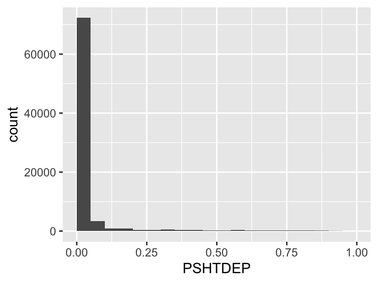

- Note that the following possible outlier values were detected: "0", "0", "0", "0", "0", …, "0.93", "0.94", "0.95", "0.95", "0.96" (1277 values omitted).

## SOCFUNC

*Social Functioning*

| Feature | Result |
| --- | --- |
| Variable type | numeric |
| Number of missing obs. | 235 (0.28 %) |
| Number of unique values | 9 |
| Median | 100 |
| 1st and 3rd quartiles | 87.5; 100 |
| Min. and max. | 0; 100 |

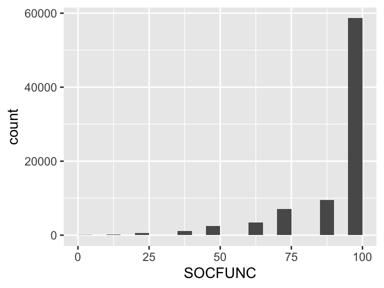

## HTNrx

*Anti-hypertensives*

- Note that this variable is treated as a factor variable below, as it only takes a few unique values.

| Feature | Result |
| --- | --- |
| Variable type | numeric |
| Number of missing obs. | 1 (0 %) |
| Number of unique values | 2 |
| Mode | “0” |
| Reference category | 0 |

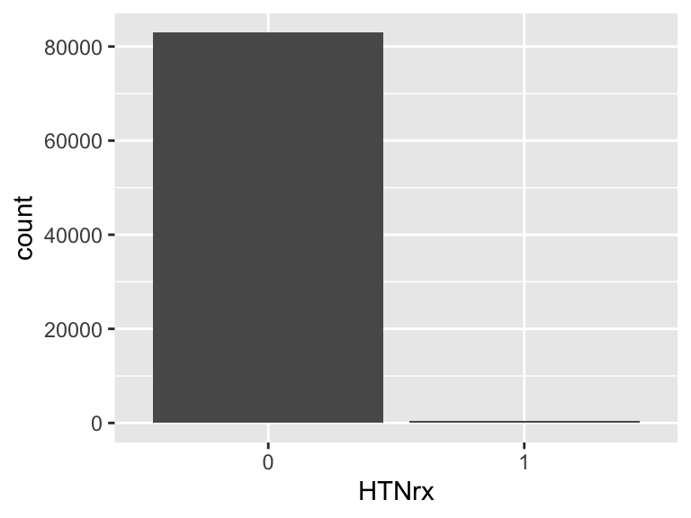

## F33PILLSHYP

*F33 Pills For Hypertension*

- Note that this variable is treated as a factor variable below, as it only takes a few unique values.

| Feature | Result |
| --- | --- |
| Variable type | numeric |
| Number of missing obs. | 0 (0 %) |
| Number of unique values | 2 |
| Mode | “0” |
| Reference category | 0 |

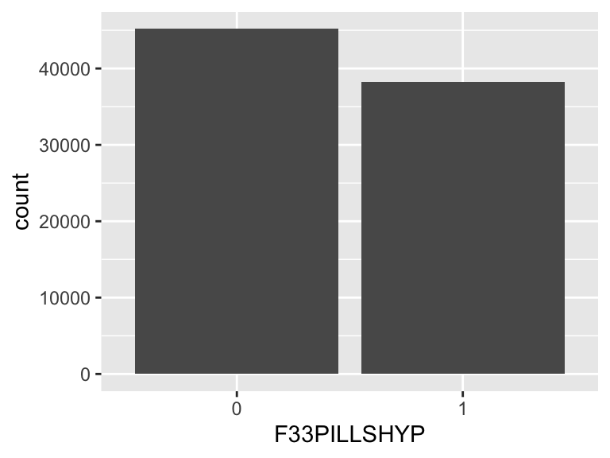

## timedy

*Days to HTN or censor*

| Feature | Result |
| --- | --- |
| Variable type | numeric |
| Number of missing obs. | 0 (0 %) |
| Number of unique values | 6547 |
| Median | 3649 |
| 1st and 3rd quartiles | 2266; 5925 |
| Min. and max. | 123; 7295 |

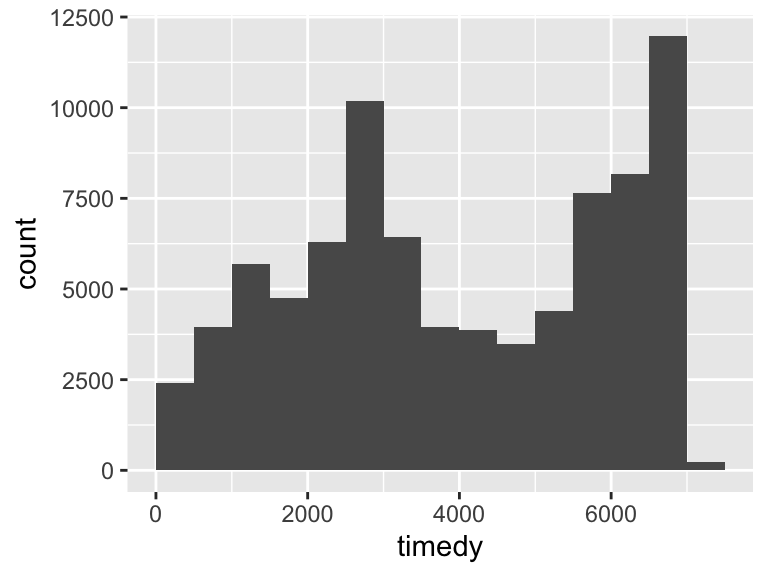

## timeyr

*Years to HTN or censor*

| Feature | Result |
| --- | --- |
| Variable type | numeric |
| Number of missing obs. | 0 (0 %) |
| Number of unique values | 6547 |
| Median | 9.99 |
| 1st and 3rd quartiles | 6.2; 16.22 |
| Min. and max. | 0.34; 19.97 |

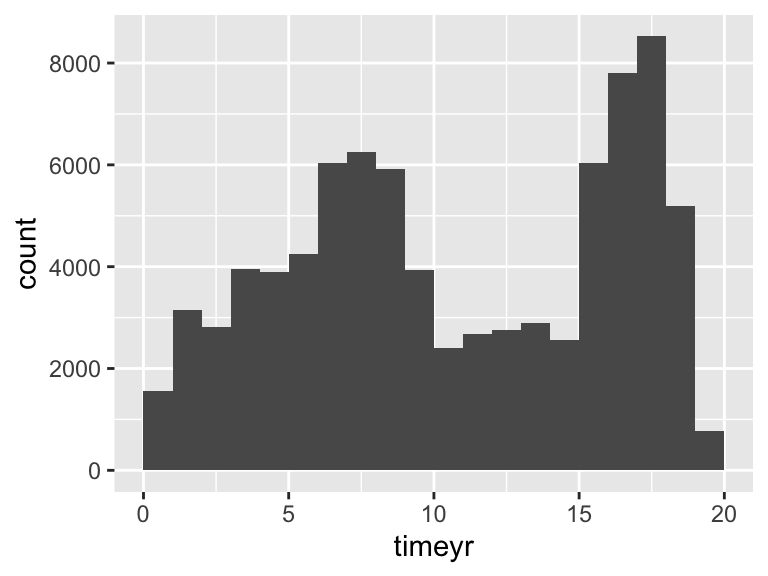

## educcat

*Education categories*

- Note that this variable is treated as a factor variable below, as it only takes a few unique values.

| Feature | Result |
| --- | --- |
| Variable type | numeric |
| Number of missing obs. | 615 (0.74 %) |
| Number of unique values | 3 |
| Mode | “1” |
| Reference category | 0 |

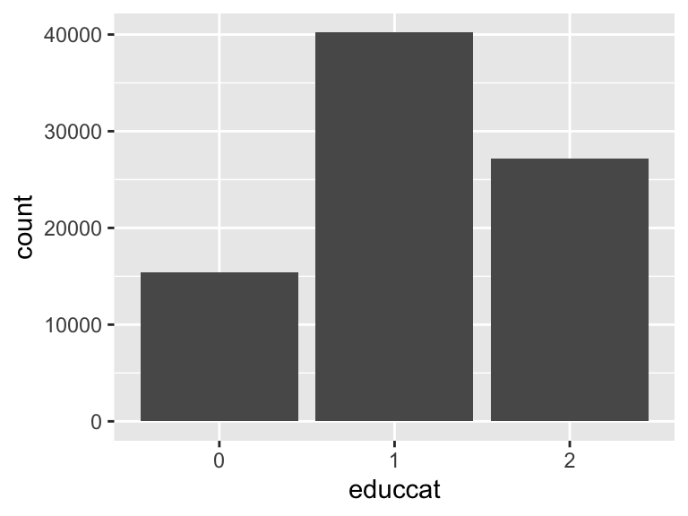

## HxCHD

*Hx CHD (MI or Revasc)*

- The variable only takes one (non-missing) value: "0". The variable contains 0 % missing observations.

## prevCanc

*Hx Cancer*

- Note that this variable is treated as a factor variable below, as it only takes a few unique values.

| Feature | Result |
| --- | --- |
| Variable type | numeric |
| Number of missing obs. | 0 (0 %) |
| Number of unique values | 2 |
| Mode | “0” |
| Reference category | 0 |

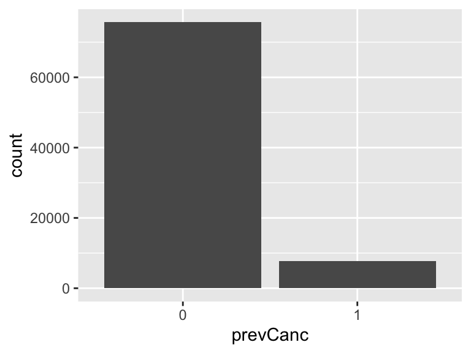

## stroke_f2

*Stroke ever*

- The variable only takes one (non-missing) value: "0". The variable contains 0 % missing observations.

Report generation information:

- Created by: Connor (username: `Connor`).
- Report creation time: Tue Nov 14 2023 14:55:19
- Report was run from directory: `/Users/Connor/Library/CloudStorage/OneDrive-Personal/Desktop/WHI Total PA & HTN R/whi-totalPA-htn`
- dataMaid v1.4.1 [Pkg: 2021-10-08 from CRAN (R 4.2.0)]
- R version 4.2.0 (2022-04-22).
- Platform: x86_64-apple-darwin17.0 (64-bit)(macOS Monterey 12.4).
- Function call: `makeDataReport(data = WHI.TotalPA.an_samp, output = "html", replace = TRUE)`